```r
library(worldfootballR)
library(tidyverse)
library(ggsoccer)
library(skimr)
library(glue)
library(patchwork)
```

This analysis is restricted to regular-season matches in Europe’s traditional ‘Top 5’ Leagues and their respective domestic cup competitions. It will also include matches in the three major continental competitions (EUROs, Copa America, AFCON) as well as the premier European club competitions (Champions, Europa and Conference League). Finally, it will also include the World Cup. This is to ensure comparability and data consistency. Before I start EDA, I’ll write a couple of functions to make visualisations of missing data. Since I’m analysing a lot of datasets, this will help streamline my code and make it more efficient. I’ll also be setting a few variables which I’ll be reusing throughout my EDA.

```r
#I used progress bars when writing this code for debug purposes, I'm disabling them here for more efficient visualisations.
options(dplyr.show_progress = FALSE)
options(purrr.show_progress = FALSE)
options(worldfootballR.progress = FALSE)

find_missing_values <- function(data, na_columns) {
  # Ensuring required columns exist (I want to return the date, competition and home/away teams where the NA values lie)
  required_columns <- c("Date", "Competition_Name", "Home", "Away")
  if (!all(required_columns %in% names(data))) {
    stop("Dataframe must contain: Date, Competition_Name, Home, and Away columns.")
  }

  if (!all(na_columns %in% names(data))) {
    stop("One or more columns in 'na_columns' do not exist in the dataframe.")
  }

  # Filtering rows with NA in any of the specified columns
  data %>%
    filter(if_any(all_of(na_columns), is.na)) %>%
    select(Date, Competition_Name, Home, Away)
}

league_list <- c("ENG", "ESP", "GER", "ITA", "FRA")
```

In the first section, I’ll perform EDA on the scraped data from the worldfootballR_data repo. I’ll start by loading match results for the top 5 European leagues for the past decade.  
Then, I’ll briefly view the data and check if there’s any gaps in important variables.

```r
topleagues_data <- load_match_results(country = league_list, gender = c("M"), season_end_year = c(2015:2025), tier = "1st")
```

```
## → Data last updated 2025-08-07 17:38:30.5505208969116 UTC
```

```r
tally(topleagues_data)
```

```
##       n
## 1 19973
```

```r
skim(topleagues_data)
```

Data summary

| Name | topleagues_data |
| --- | --- |
| Number of rows | 19973 |
| Number of columns | 20 |
| _______________________ |  |
| Column type frequency: |  |
| character | 13 |
| Date | 1 |
| numeric | 6 |
| ________________________ |  |
| Group variables | None |

**Variable type: character**

| skim_variable | n_missing | complete_rate | min | max | empty | n_unique | whitespace |
| --- | --- | --- | --- | --- | --- | --- | --- |
| Competition_Name | 0 | 1.00 | 7 | 18 | 0 | 5 | 0 |
| Gender | 0 | 1.00 | 1 | 1 | 0 | 1 | 0 |
| Country | 0 | 1.00 | 3 | 3 | 0 | 5 | 0 |
| Round | 13986 | 0.30 | 7 | 41 | 0 | 11 | 0 |
| Wk | 35 | 1.00 | 1 | 2 | 0 | 38 | 0 |
| Day | 0 | 1.00 | 3 | 3 | 0 | 7 | 0 |
| Time | 0 | 1.00 | 0 | 5 | 73 | 51 | 0 |
| Home | 0 | 1.00 | 3 | 15 | 0 | 168 | 0 |
| Away | 0 | 1.00 | 3 | 15 | 0 | 168 | 0 |
| Venue | 0 | 1.00 | 7 | 43 | 0 | 219 | 0 |
| Referee | 0 | 1.00 | 0 | 26 | 131 | 279 | 0 |
| Notes | 12847 | 0.36 | 0 | 74 | 6984 | 26 | 0 |
| MatchURL | 0 | 1.00 | 66 | 122 | 0 | 19973 | 0 |

**Variable type: Date**

| skim_variable | n_missing | complete_rate | min | max | median | n_unique |
| --- | --- | --- | --- | --- | --- | --- |
| Date | 0 | 1 | 2014-08-08 | 2025-05-29 | 2019-12-21 | 2051 |

**Variable type: numeric**

| skim_variable | n_missing | complete_rate | mean | sd | p0 | p25 | p50 | p75 | p100 | hist |
| --- | --- | --- | --- | --- | --- | --- | --- | --- | --- | --- |
| Season_End_Year | 0 | 1.00 | 2019.97 | 3.15 | 2015 | 2017.0 | 2020.0 | 2023.00 | 2025.0 | ▇▆▆▆▅ |
| HomeGoals | 101 | 0.99 | 1.54 | 1.31 | 0 | 1.0 | 1.0 | 2.00 | 10.0 | ▇▂▁▁▁ |
| Home_xG | 5616 | 0.72 | 1.49 | 0.83 | 0 | 0.9 | 1.4 | 2.00 | 7.0 | ▇▆▁▁▁ |
| AwayGoals | 101 | 0.99 | 1.23 | 1.17 | 0 | 0.0 | 1.0 | 2.00 | 9.0 | ▇▃▁▁▁ |
| Away_xG | 5616 | 0.72 | 1.22 | 0.74 | 0 | 0.7 | 1.1 | 1.60 | 5.6 | ▇▆▁▁▁ |
| Attendance | 2283 | 0.89 | 30446.91 | 18369.58 | 13 | 16121.0 | 25913.5 | 41443.25 | 230506.0 | ▇▂▁▁▁ |

There’s a lot of NA values, especially for xG. I’ll use the naniar package to visually inspect where these values are.

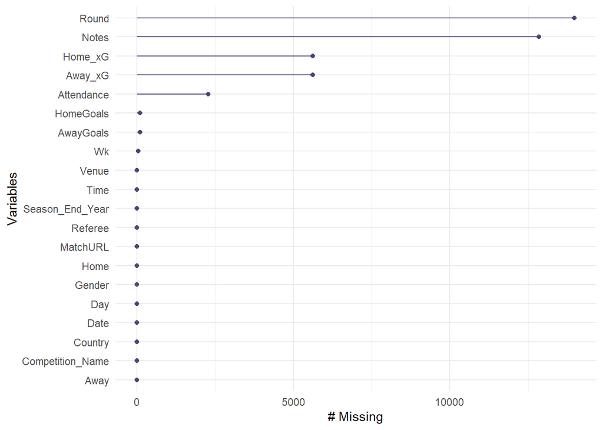

```r
library(naniar)
gg_miss_var(topleagues_data)
```

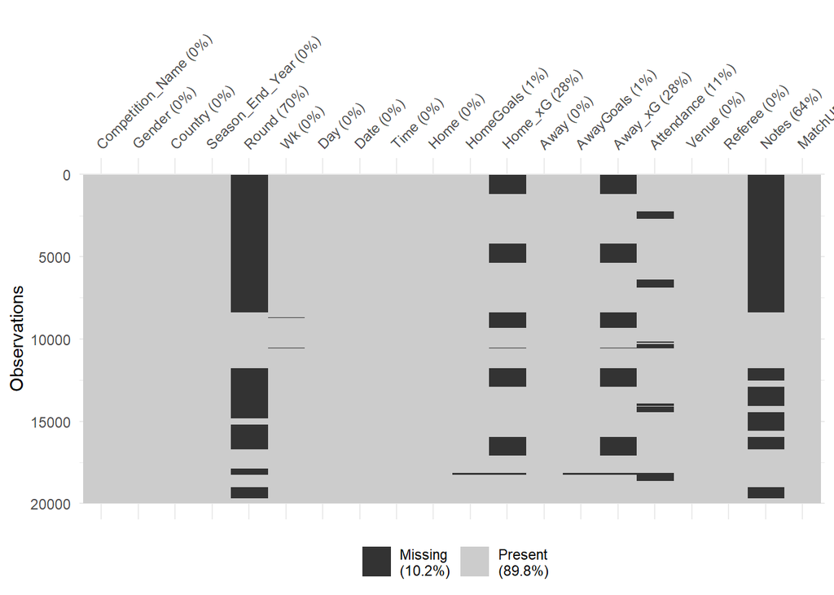

```r
vis_miss(topleagues_data)
```

A lot of NA values for Round is plausible (these are usually reserved for cup competitions).  
It’s important to note the missing Attendance values, however.  
It appears the xG values that are missing originate at the beginning of the data for each league. There are five blocks of missing xG data which corresponds to the five leagues I’ve imported.  
These blocks appear to be at the start of the data, which could mean xG data is only availabe past a certain year.  
I’ll import a new dataset starting from a later year and run the same test to double-check.

```r
recent_topleagues_data <- load_match_results(country = c("ENG", "ESP", "GER", "ITA", "FRA"), gender = c("M"), season_end_year = c(2018:2025), tier = "1st")
```

```
## → Data last updated 2025-08-07 17:38:30.5505208969116 UTC
```

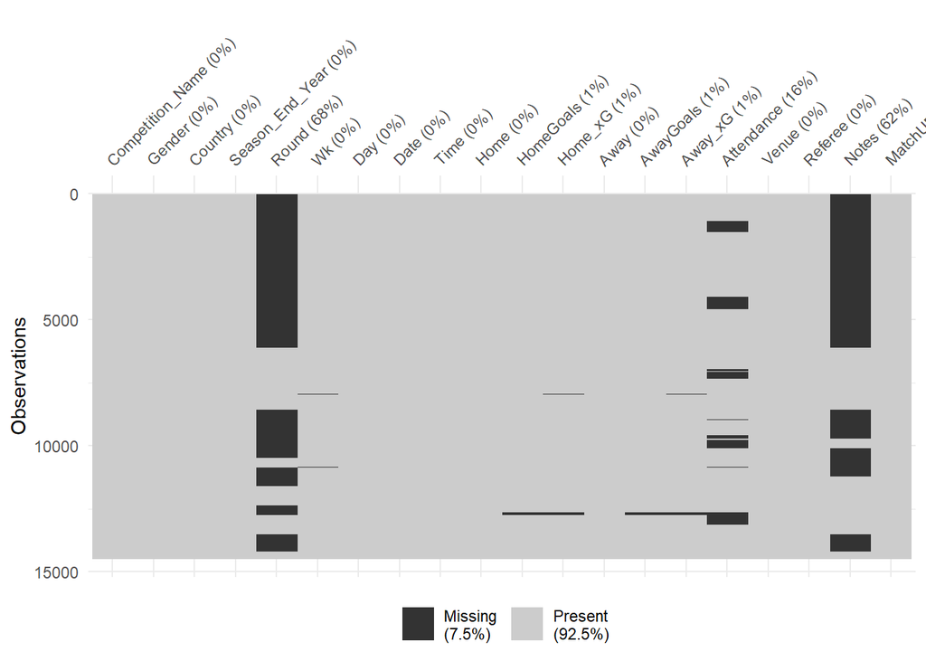

```r
vis_miss(recent_topleagues_data)
```

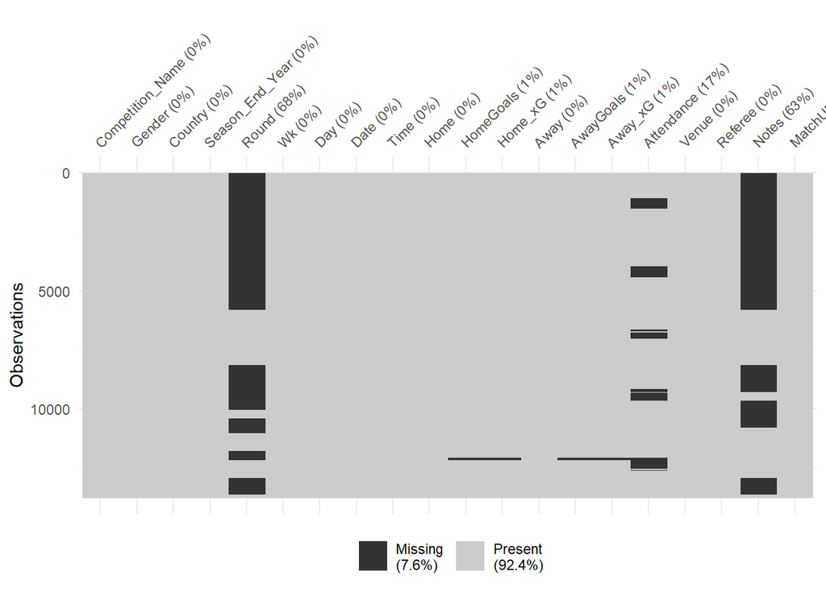

```r
topleagues_data <- topleagues_data %>%
  mutate(Date = as.Date(Date))
recent_topleagues_before_February <- recent_topleagues_data %>%
  filter(Date < as.Date("2025-02-04"))
vis_miss(recent_topleagues_before_February)
```

Only 1% of the xG data remains missing. I’ll make a new dataframe with just those rows and inspect it to see where the missing data is.

```r
missing_xg_rows <- find_missing_values(recent_topleagues_before_February, c("Home_xG", "Away_xG"))
skim(missing_xg_rows)
```

Data summary

| Name | missing_xg_rows |
| --- | --- |
| Number of rows | 125 |
| Number of columns | 4 |
| _______________________ |  |
| Column type frequency: |  |
| character | 3 |
| Date | 1 |
| ________________________ |  |
| Group variables | None |

**Variable type: character**

| skim_variable | n_missing | complete_rate | min | max | empty | n_unique | whitespace |
| --- | --- | --- | --- | --- | --- | --- | --- |
| Competition_Name | 0 | 1 | 7 | 18 | 0 | 3 | 0 |
| Home | 0 | 1 | 4 | 13 | 0 | 35 | 0 |
| Away | 0 | 1 | 4 | 13 | 0 | 36 | 0 |

**Variable type: Date**

| skim_variable | n_missing | complete_rate | min | max | median | n_unique |
| --- | --- | --- | --- | --- | --- | --- |
| Date | 0 | 1 | 2018-05-17 | 2024-05-27 | 2020-04-26 | 40 |

There’s only 125 rows, which means the select() function showed the whole dataframe.  
The Ligue 1 (French league) 2019/20 season was suspended on March 13 2020 due to the coronavirus and cancelled on April 20, therefore those matches were never actually played. This explains why there is no xG data for Ligue 1 during this timeframe.  
The remaining missing Ligue 1 and Bundesliga data (except for one game) is because those games were the relegation play-offs of those leagues. These two leagues are the only top 5 leagues that adopt a system of relegation play-offs. This is a system whereby 16th place in the league (third from bottom) plays 3rd place from the second tier in two games: one home and one away. The winner, decided by aggregate score, either remains or is promoted to the first divison for next season. The loser remains/is relegated to the second division. It’s arguable as to whether these games count towards the league. Since they don’t comprise of the 38 (or 34) games each team plays in a standard league season, I won’t count them. It feels unfair to take stats for some teams playing 34 games and others playing 36.  
There’s one Bundesliga game that wasn’t a playoff, however, which was the Bochum vs M’Gladbach match on 2022-03-18. It’s clear this isn’t a playoff game because there was no return game between Gladbach and Bochum (all of the playoffs are in pairs). This game also took place mid-season while the other games took place between May and July (att he end of the season). In this game, Gladbach led 2-0 at around the 68-70th minute when assistant referee Christian Gittelmann was struck in the head by a beer cup thrown from the crowd at Bochum’s stadium. This resulted in a serious injury and referee Benjamin Cortus abandoned the match shortly after for security reasons. The German Football Association awarded the game as a Gladbach 2-0 win as opposed to a replay. Bochum’s appeal for a replay was later withdrew.  
The final outlier is the September 2020 game between Hellas Verona and Roma in Italy’s Serie A. The game ended 0-0 in regulation time, however Verona was awarded a 3-0 forfeit win by the Italian Football Federation afterwards. This is because Roma fielded an ineligible player (Amadou Diawara) who had just turned 23 but was registered in the under-22 registration list. It was a small mistake, but it gave Verona the win. This is probably the reason why the xG and goal count wasn’t collected in the dataset.  
In conclusion, there are two outliers to look out for when analysing Bundesliga and Serie A data, and Ligue 1 data analysis for the 2019/20 season will be skewed because of its cancellation.  
Now, I’ll do the same tests on data from the most prominent football cup competitions worldwide (domestic and international). I’ll also take a quick look at them and check for missing data.

```r
cups <- c("Africa Cup of Nations", "CONMEBOL Copa América", "Copa del Rey", "Coppa Italia", "Coupe de France", " DFB-Pokal", "EFL Cup", "FA Cup", "FIFA World Cup", "UEFA Champions League", "UEFA Conference League", "UEFA Europa League", "UEFA European Football Championship")
cups_data <- load_match_comp_results(comp_name = cups)
```

```
## → Data last updated 2024-02-15 17:17:59.4536941051483 UTC
```

```r
skim(cups_data)
```

Data summary

| Name | cups_data |
| --- | --- |
| Number of rows | 20003 |
| Number of columns | 20 |
| _______________________ |  |
| Column type frequency: |  |
| character | 13 |
| Date | 1 |
| numeric | 6 |
| ________________________ |  |
| Group variables | None |

**Variable type: character**

| skim_variable | n_missing | complete_rate | min | max | empty | n_unique | whitespace |
| --- | --- | --- | --- | --- | --- | --- | --- |
| Competition_Name | 0 | 1.00 | 6 | 35 | 0 | 13 | 0 |
| Gender | 0 | 1.00 | 1 | 1 | 0 | 1 | 0 |
| Country | 12580 | 0.37 | 3 | 3 | 0 | 5 | 0 |
| Round | 0 | 1.00 | 5 | 24 | 0 | 28 | 0 |
| Wk | 10013 | 0.50 | 0 | 2 | 2965 | 13 | 0 |
| Day | 0 | 1.00 | 3 | 3 | 0 | 7 | 0 |
| Time | 981 | 0.95 | 0 | 5 | 5996 | 92 | 0 |
| Home | 0 | 1.00 | 3 | 35 | 0 | 2280 | 0 |
| Away | 0 | 1.00 | 3 | 35 | 0 | 1866 | 0 |
| Venue | 0 | 1.00 | 0 | 58 | 4421 | 2192 | 0 |
| Referee | 192 | 0.99 | 0 | 30 | 1015 | 2145 | 0 |
| Notes | 328 | 0.98 | 0 | 96 | 12915 | 1055 | 0 |
| MatchURL | 0 | 1.00 | 69 | 123 | 0 | 19995 | 0 |

**Variable type: Date**

| skim_variable | n_missing | complete_rate | min | max | median | n_unique |
| --- | --- | --- | --- | --- | --- | --- |
| Date | 0 | 1 | 1930-07-13 | 2025-02-26 | 2016-02-18 | 3067 |

**Variable type: numeric**

| skim_variable | n_missing | complete_rate | mean | sd | p0 | p25 | p50 | p75 | p100 | hist |
| --- | --- | --- | --- | --- | --- | --- | --- | --- | --- | --- |
| Season_End_Year | 0 | 1.00 | 2012.77 | 11.60 | 1930 | 2006.00 | 2016.0 | 2021.0 | 2025.0 | ▁▁▁▂▇ |
| HomeGoals | 165 | 0.99 | 1.54 | 1.40 | 0 | 0.00 | 1.0 | 2.0 | 15.0 | ▇▁▁▁▁ |
| AwayGoals | 165 | 0.99 | 1.29 | 1.31 | 0 | 0.00 | 1.0 | 2.0 | 12.0 | ▇▁▁▁▁ |
| Attendance | 9135 | 0.54 | 21443.63 | 21733.08 | 11 | 3792.75 | 13073.0 | 34803.0 | 173850.0 | ▇▂▁▁▁ |
| Home_xG | 16840 | 0.16 | 1.57 | 0.91 | 0 | 0.90 | 1.4 | 2.1 | 6.8 | ▇▇▂▁▁ |
| Away_xG | 16840 | 0.16 | 1.26 | 0.81 | 0 | 0.70 | 1.1 | 1.7 | 7.1 | ▇▃▁▁▁ |

There’s a lot of data here, though the most important is xG. I’ll perform the same visual inspection of missing values.

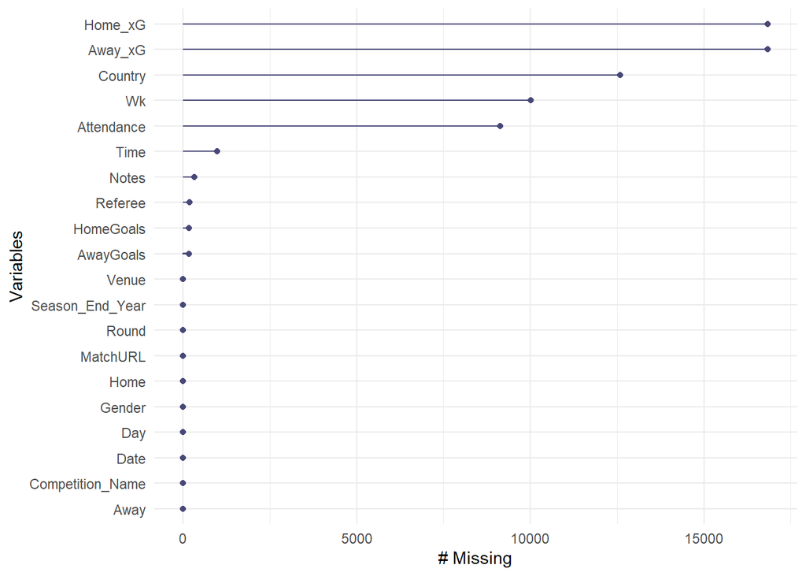

```r
gg_miss_var(cups_data)
```

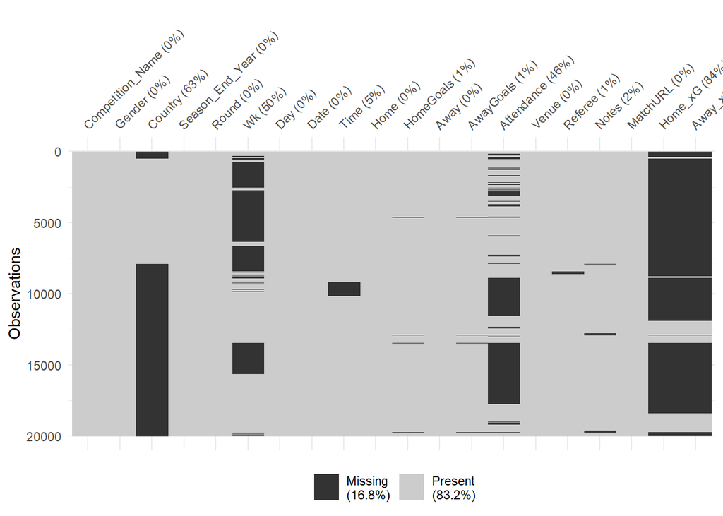

```r
vis_miss(cups_data)
```

There’s quite a lot of missing xG data. I’ll first filter out all data before the 2017/18 season, as this is when xG collection began. I’ll do the same step of converting the Date column values to have the Date data type.  
The other missing valuesw like Week and Attendance don’t matter as much (Week can be pulled from the Date) and attendance isn’t necessary for player/team analysis.

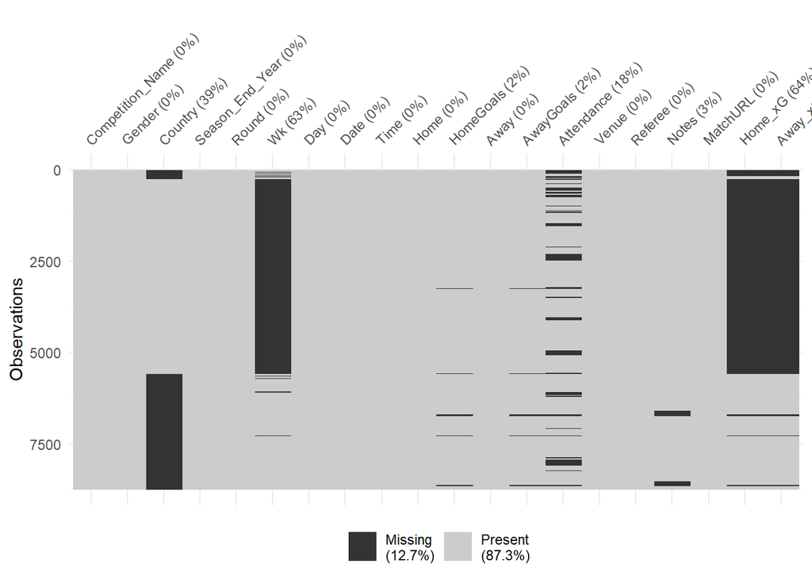

```r
cups_data <- cups_data %>%
  mutate(Date = as.Date(Date))
filtered_cups_data <- filter(cups_data, Date > as.Date("2017-06-06"))
vis_miss(filtered_cups_data)
```

It’s better, going from 84% missing to 64% missing, though there’s still a lot of missing data. I’ll filter out the rows with missing xG and look at them now.

```r
missing_cup_xg_rows <- find_missing_values(filtered_cups_data, c("Home_xG", "Away_xG"))
skim(missing_cup_xg_rows)
```

Data summary

| Name | missing_cup_xg_rows |
| --- | --- |
| Number of rows | 5588 |
| Number of columns | 4 |
| _______________________ |  |
| Column type frequency: |  |
| character | 3 |
| Date | 1 |
| ________________________ |  |
| Group variables | None |

**Variable type: character**

| skim_variable | n_missing | complete_rate | min | max | empty | n_unique | whitespace |
| --- | --- | --- | --- | --- | --- | --- | --- |
| Competition_Name | 0 | 1 | 6 | 22 | 0 | 10 | 0 |
| Home | 0 | 1 | 3 | 35 | 0 | 1452 | 0 |
| Away | 0 | 1 | 3 | 35 | 0 | 1095 | 0 |

**Variable type: Date**

| skim_variable | n_missing | complete_rate | min | max | median | n_unique |
| --- | --- | --- | --- | --- | --- | --- |
| Date | 0 | 1 | 2017-07-29 | 2025-02-26 | 2021-04-20 | 796 |

```r
stat_types <- c("standard", "shooting", "passing", "passing_types", "gca",
                "defense", "possession", "playing_time", "misc",
                "keepers", "keepers_adv")

seasons <- 2018:2025

# Function to load data with error handling
load_tagged_stats <- function(stat_type, team_or_player) {
  tryCatch({
    Sys.sleep(3)
    data <- fb_big5_advanced_season_stats(
      stat_type = stat_type,
      season_end_year = seasons,
      team_or_player = team_or_player
    )

    if (!is.null(data) && nrow(data) > 0) {
      data <- data %>% mutate(Stat_Type = stat_type, Level = team_or_player)
      return(data)
    } else {
      return(NULL)
    }
  }, error = function(e) {
    return(NULL)
  })
}


# Function to sample dataframes
sample_df <- function(df, n = 100) {
  if (is.null(df) || nrow(df) == 0) return(NULL)
  df %>% slice_sample(n = min(n, nrow(df)))
}

# Cleaned missing data visualization function
plot_missing_summary <- function(df, stat_type, level, top_n = 8) {
  if (is.null(df) || nrow(df) == 0) return(NULL)

  missing_summary <- df %>%
    summarise(across(everything(), ~mean(is.na(.)) * 100)) %>%
    pivot_longer(cols = everything(), names_to = "variable", values_to = "missing_pct") %>%
    filter(missing_pct > 0) %>%
    arrange(desc(missing_pct)) %>%
    slice_head(n = top_n) %>%
    mutate(
      variable = fct_reorder(variable, missing_pct),
      variable_clean = variable %>%
        str_replace_all("_", " ") %>%
        str_replace_all("1er", "Per") %>%
        str_replace_all("Prcent", "Percent") %>%
        str_replace_all("pct", "Percent") %>%
        str_replace_all("90s", "Per 90") %>%
        str_to_title() %>%
        str_replace_all("\\bPer\\b", "per") %>%
        str_replace_all("\\bAnd\\b", "and") %>%
        str_replace_all("\\bOf\\b", "of") %>%
        str_replace_all("\\bIn\\b", "in") %>%
        str_replace_all("\\bTo\\b", "to") %>%
        str_trunc(30)
    )

  if (nrow(missing_summary) == 0) {
    return(
      ggplot() +
        annotate("text", x = 0.5, y = 0.5, label = "No Missing Data",
                 size = 4, color = "darkgreen", fontface = "bold") +
        labs(title = glue("{str_to_title(level)} - {str_to_title(stat_type)}")) +
        theme_void() +
        theme(plot.title = element_text(hjust = 0.5, size = 10, face = "bold"))
    )
  }

  fill_color <- case_when(
    max(missing_summary$missing_pct) > 50 ~ "#d73027",
    max(missing_summary$missing_pct) > 25 ~ "#fc8d59",
    TRUE ~ "#fee08b"
  )

  ggplot(missing_summary, aes(x = reorder(variable_clean, missing_pct), y = missing_pct)) +
    geom_col(fill = fill_color, alpha = 0.8, width = 0.7) +
    geom_text(aes(label = paste0(round(missing_pct, 1), "%")),
              hjust = -0.1, size = 2.5, color = "black", fontface = "bold") +
    coord_flip() +
    labs(
      title = glue("{str_to_title(level)} - {str_to_title(stat_type)}"),
      x = NULL,
      y = "Missing %"
    ) +
    theme_minimal() +
    theme(
      plot.title = element_text(hjust = 0.5, size = 10, face = "bold"),
      axis.text.y = element_text(size = 8, hjust = 1),
      axis.text.x = element_text(size = 8),
      axis.title.x = element_text(size = 8),
      panel.grid.minor = element_blank(),
      panel.grid.major.y = element_blank(),
      plot.margin = margin(5, 5, 5, 5)
    ) +
    scale_y_continuous(expand = expansion(mult = c(0, 0.15))) +
    scale_x_discrete(expand = expansion(add = 0.3))
}

# Load data
player_data_list <- map(stat_types, ~ load_tagged_stats(.x, "player")) %>%
  set_names(stat_types)

team_data_list <- map(stat_types, ~ load_tagged_stats(.x, "team")) %>%
  set_names(stat_types)


# First, create the missing data plots
player_missing_season_plots <- map2(player_data_list, names(player_data_list),
                                   ~plot_missing_summary(.x, .y, "player"))

team_missing_season_plots <- map2(team_data_list, names(team_data_list),
                                 ~plot_missing_summary(.x, .y, "team"))

# Print player plots individually
cat("\n=== PLAYER DATA MISSING PLOTS ===\n")
```

```
##
## === PLAYER DATA MISSING PLOTS ===
```

```
## Player Plot 1: standard
```

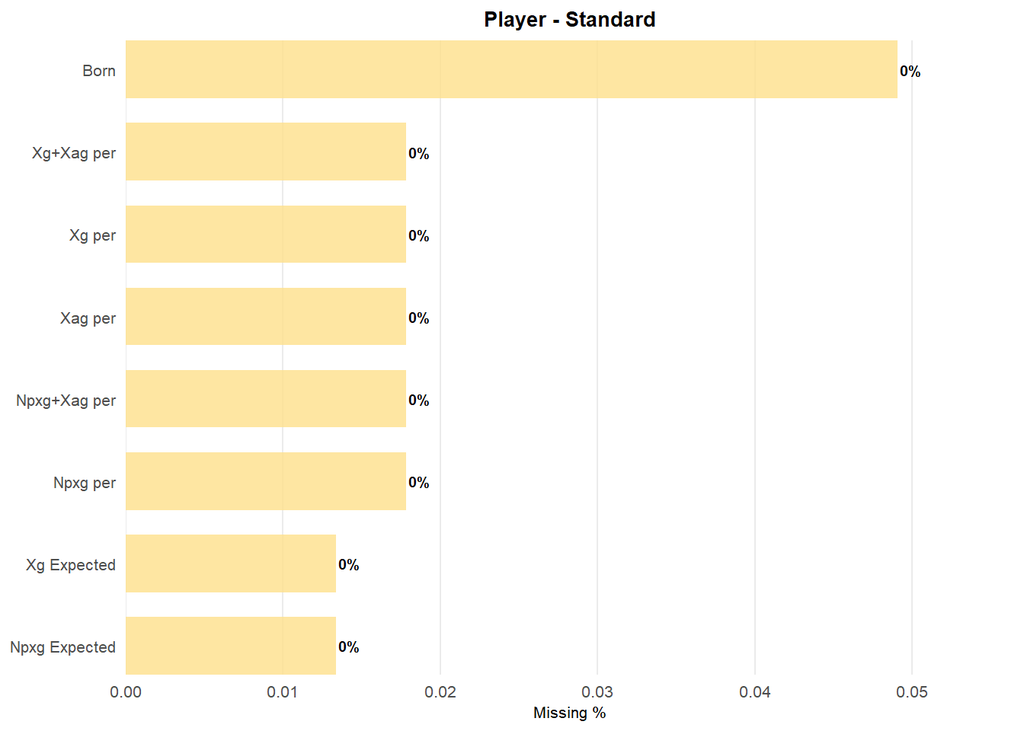

```
## Player Plot 2: shooting
```

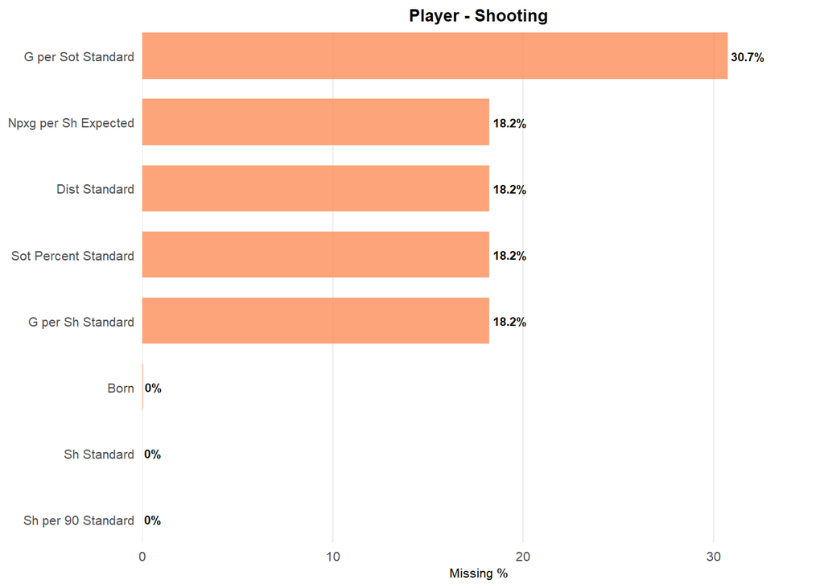

```
## Player Plot 3: passing
```

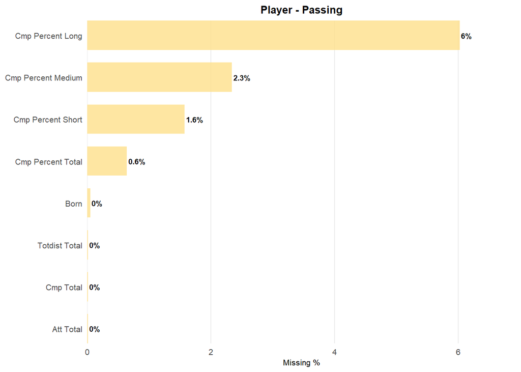

```
## Player Plot 4: passing_types
```

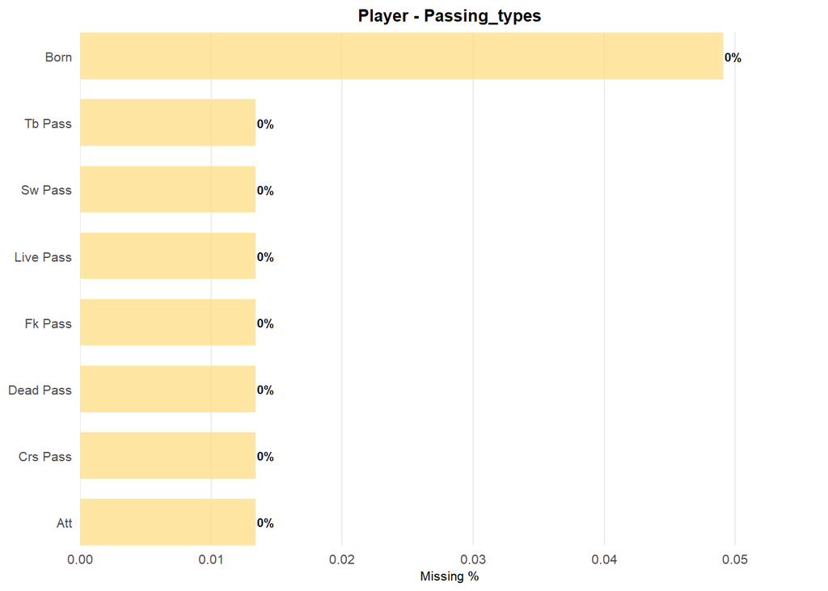

```
## Player Plot 5: gca
```

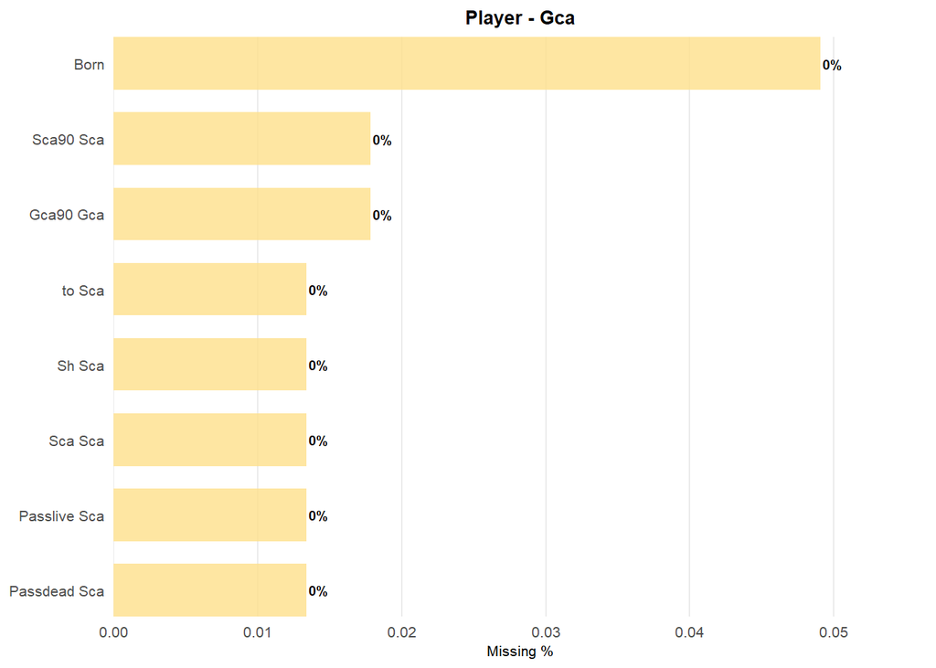

```
## Player Plot 6: defense
```

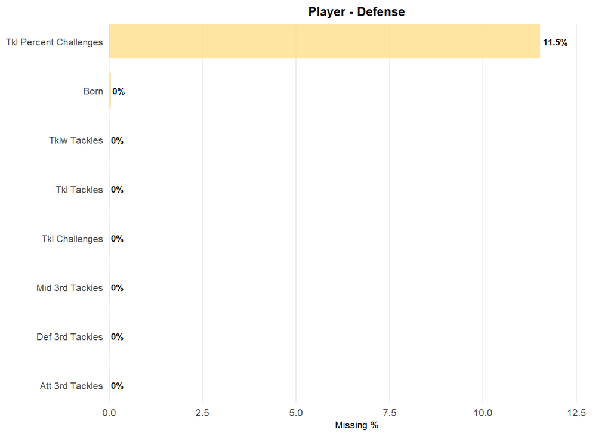

```
## Player Plot 7: possession
```

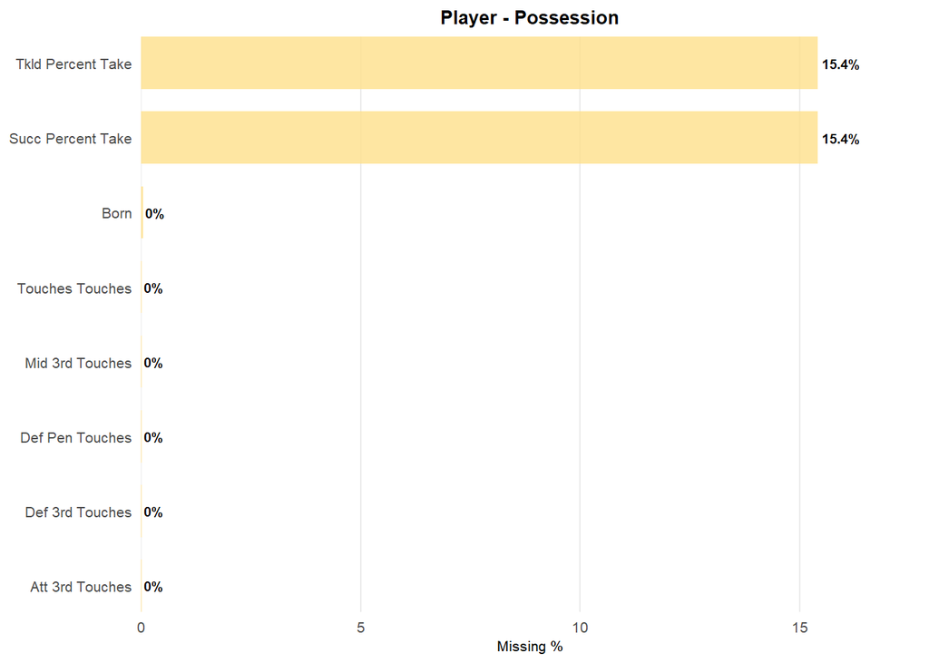

```
## Player Plot 8: playing_time
```

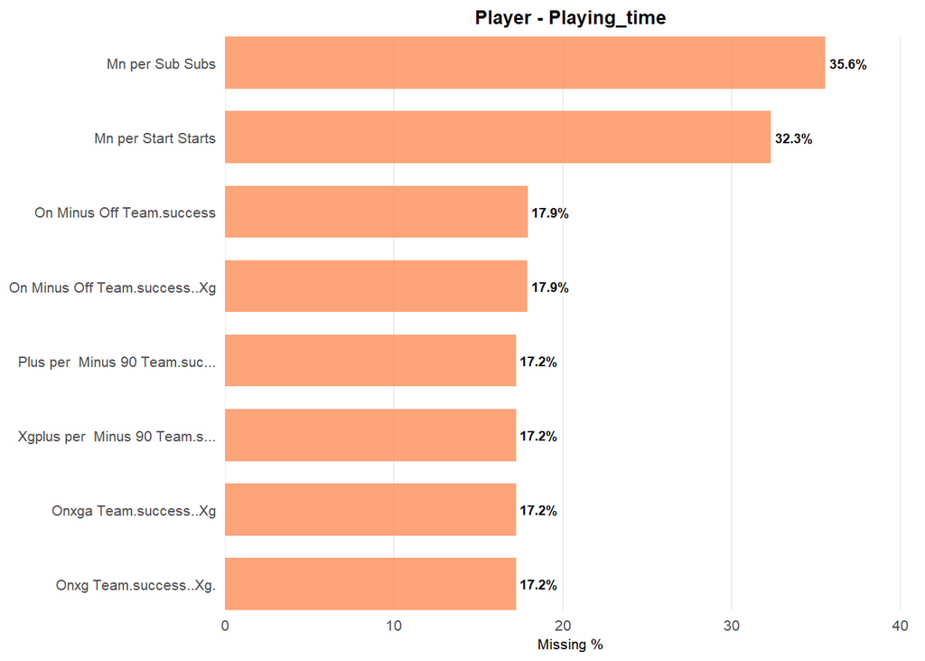

```
## Player Plot 9: misc
```

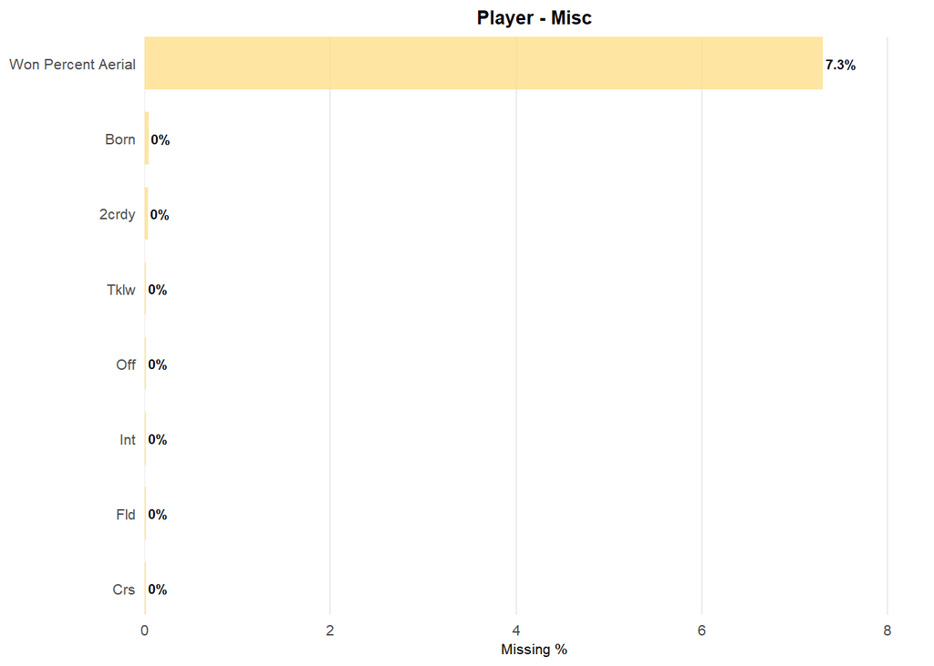

```
## Player Plot 10: keepers
```

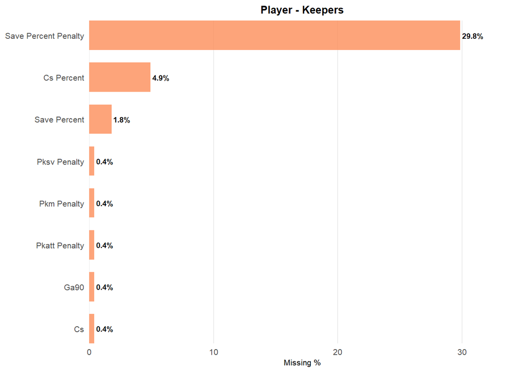

```
## Player Plot 11: keepers_adv
```

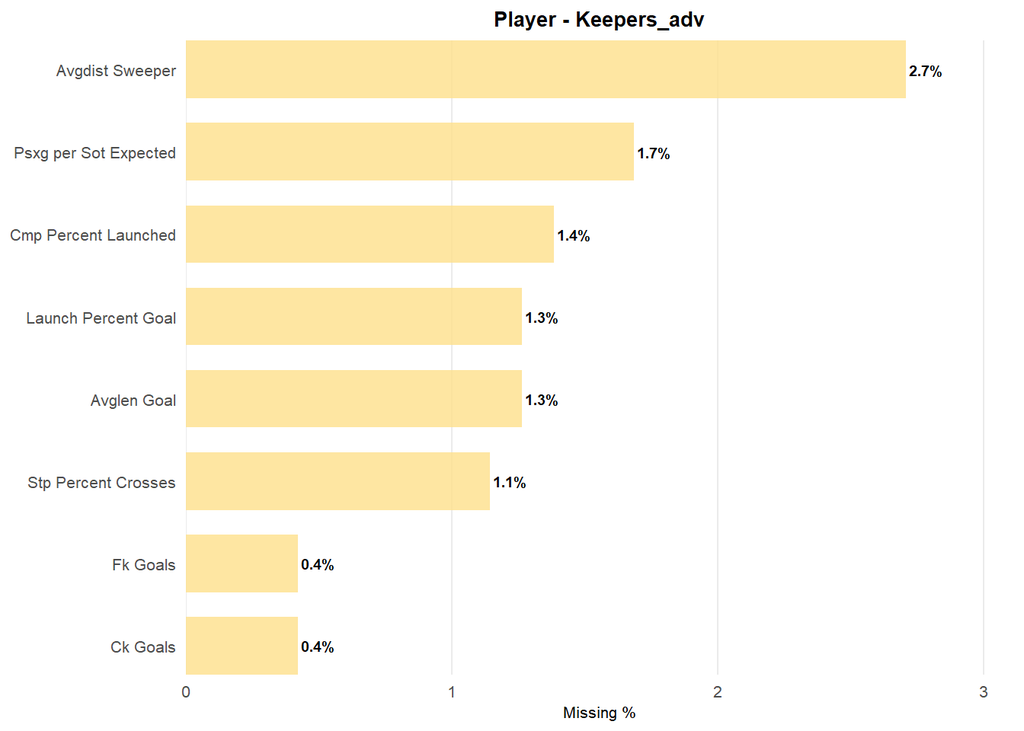

```r
for (i in seq_along(player_missing_season_plots)) {
  cat(glue::glue("\nPlayer Plot {i}: {names(player_missing_season_plots)[i]}\n"))
  print(player_missing_season_plots[[i]])
}
```

```r
# Print team plots individually
cat("\n=== TEAM DATA MISSING PLOTS ===\n")
```

```
##
## === TEAM DATA MISSING PLOTS ===
```

```
## Team Plot 1: standard
```

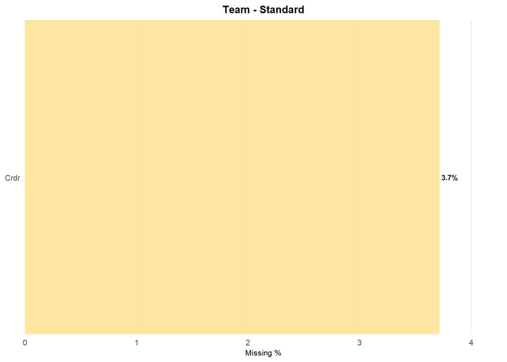

```
## Team Plot 2: shooting
```

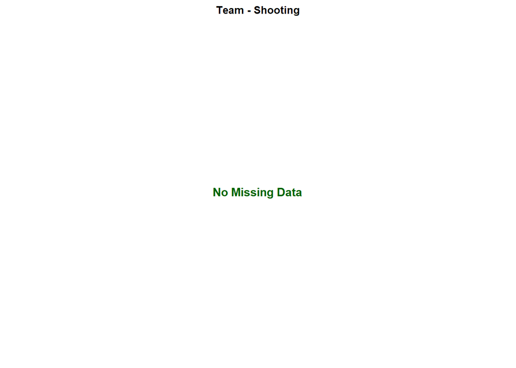

```
## Team Plot 3: passing
```

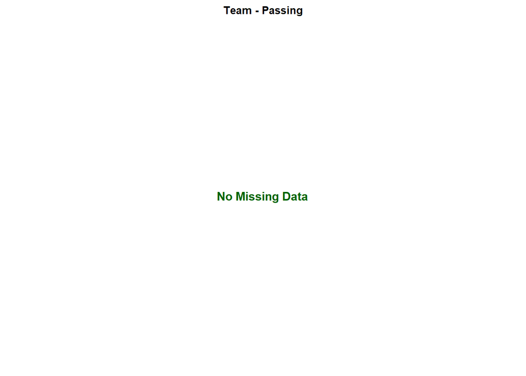

```
## Team Plot 4: passing_types
```

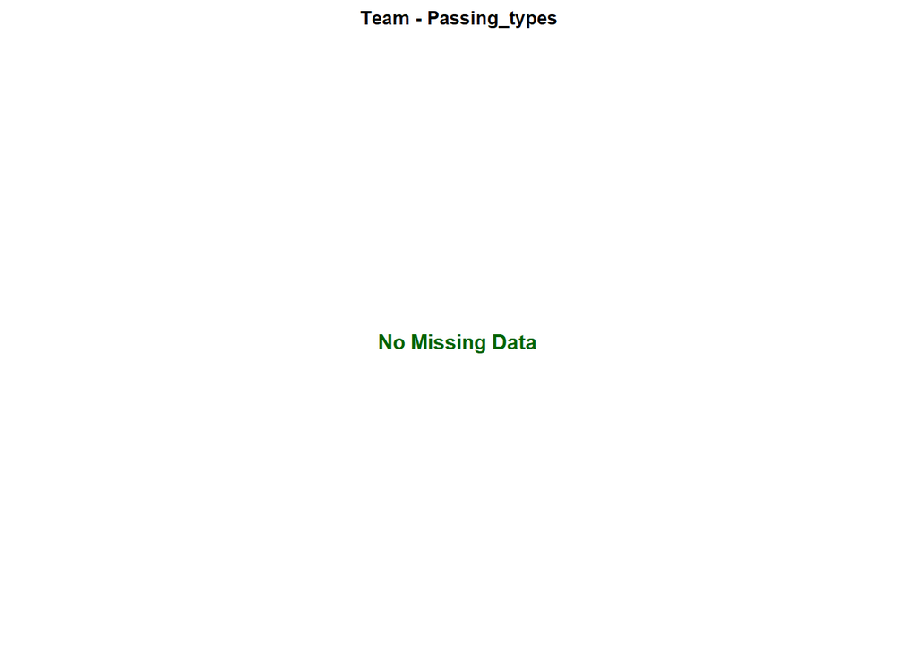

```
## Team Plot 5: gca
```

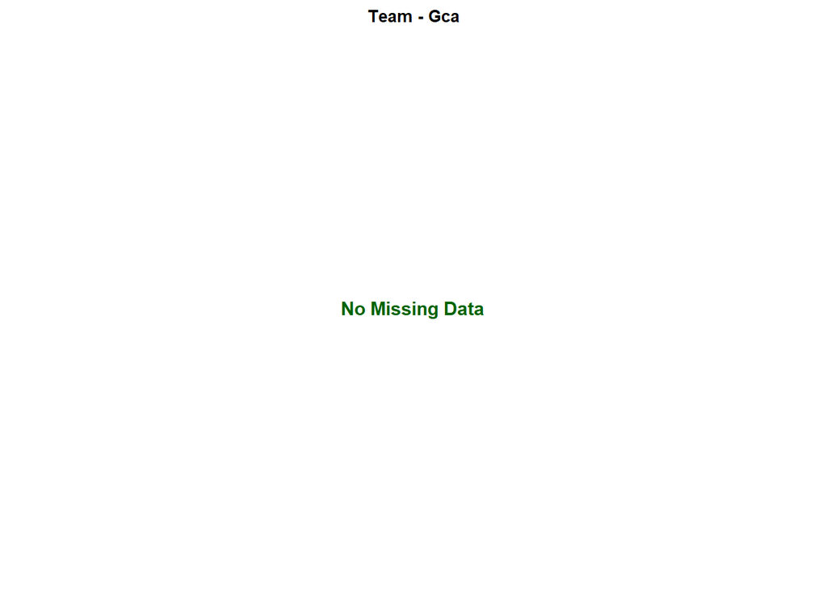

```
## Team Plot 6: defense
```

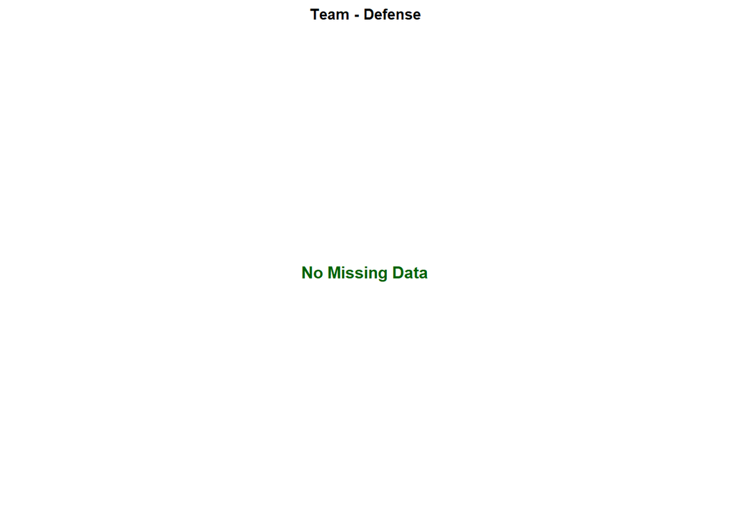

```
## Team Plot 7: possession
```

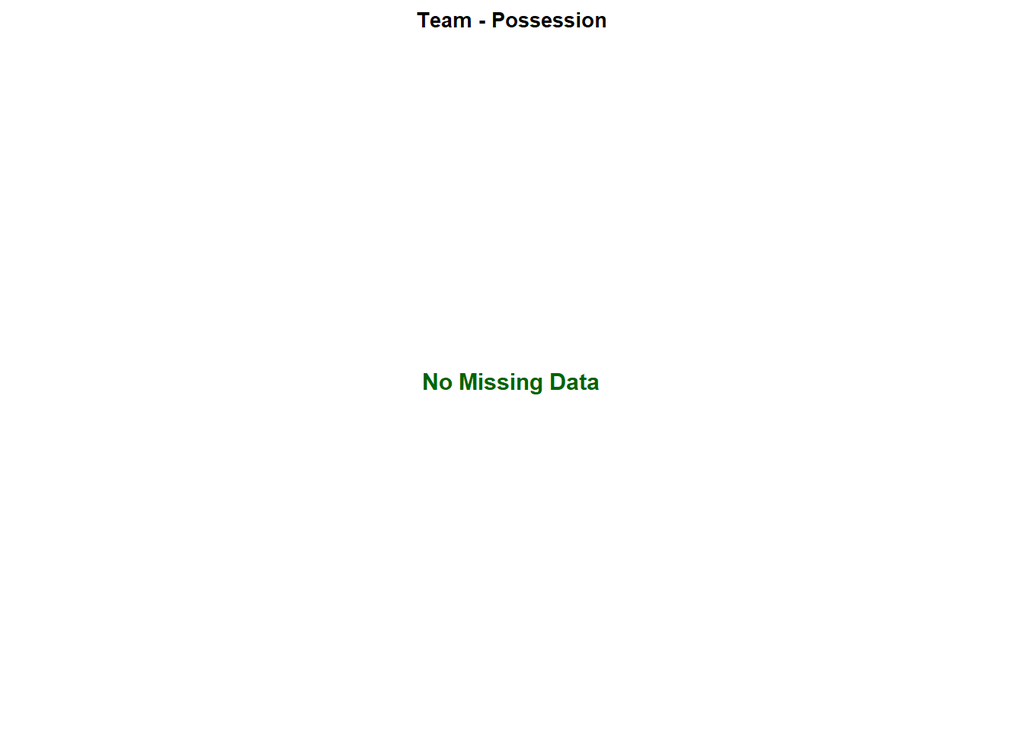

```
## Team Plot 8: playing_time
```

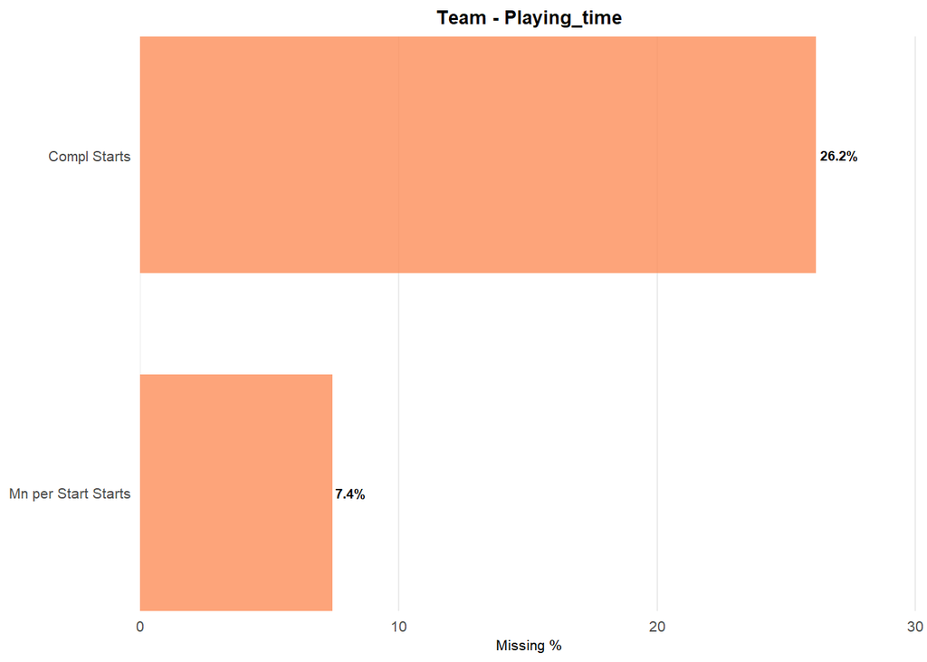

```
## Team Plot 9: misc
```

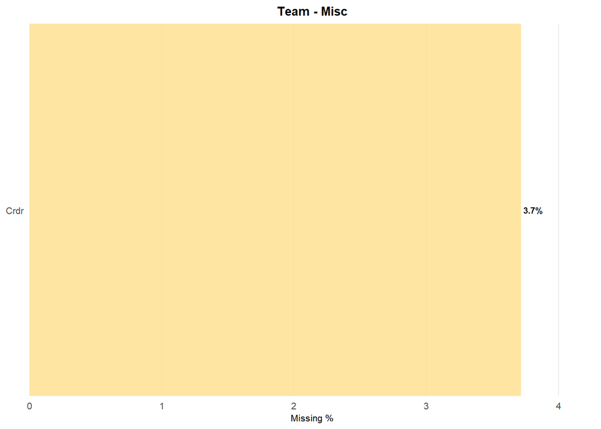

```
## Team Plot 10: keepers
```

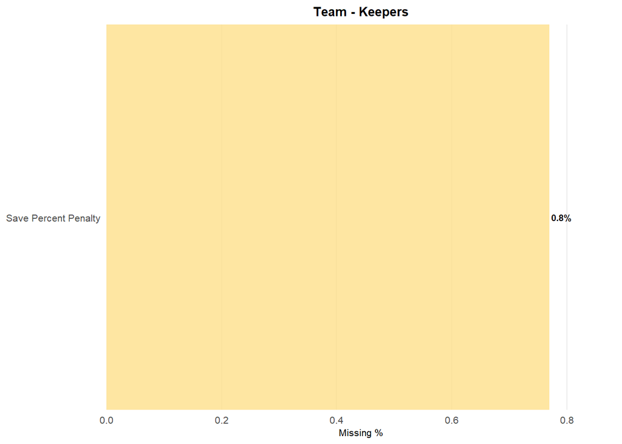

```
## Team Plot 11: keepers_adv
```

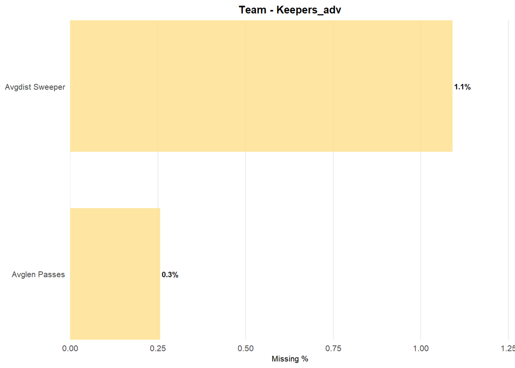

```r
for (i in seq_along(team_missing_season_plots)) {
  cat(glue::glue("\nTeam Plot {i}: {names(team_missing_season_plots)[i]}\n"))
  print(team_missing_season_plots[[i]])
}
```